# Using Natural Language Processing on News articles to find the sentiment of the news realted to Gold

**Intro to Data Analysis and Machine Learning**

Here we are using multipple techniques to find news related to gold on internet. We are using packages like NewsCatcher to go through websites like Guardian and finding if they have any top news related to gold on them to stay updated on latest trend.

We are using Google news to find recent top news on gold.

After that we are using BeautifulSoup and request to go through diffrent articles and doing sentiment analysis on them. We are doing sentiment analysis using multiple ways.

- Textblob
- Pattern

We are generating word cloud for all the news for visualizing unstructured text data and getting insights on trends and patterns.

## Installing required packages and dependancies

```python
!pip install pattern
```

```python
!pip install pygooglenews
```

```python
!pip install newscatcher
```

```python
# Imprting required libraries

import requests
import nltk
from bs4 import BeautifulSoup
import urllib.request,sys,time
import numpy as np
import pandas as pd
import seaborn as sns
import matplotlib.pyplot as plt
%matplotlib inline
import random
from wordcloud import WordCloud
import os
import spacy
nlp = spacy.load('en_core_web_sm')
nltk.download('punkt')
nltk.download('omw-1.4')
nltk.download('stopwords')
from textblob import TextBlob
from pattern.en import sentiment
```

## News from NewsCatcher

```python
from newscatcher import Newscatcher, describe_url

newcatcher_news = []

mm = Newscatcher(website = 'https://www.theguardian.com/us')

for index, headline in enumerate(mm.get_headlines()):
   newcatcher_news.append(headline)

print(newcatcher_news)
```

```
['Twitter moderators turn to automation amid a reported surge in hate speech', 'FTX chief Sam Bankman-Fried says he ‘screwed up’ but rejects fraud claim', 'Musk says brain chip to begin human trials soon – and plans to get one himself', 'Password app LastPass hit by cybersecurity breach but says dat…
```

```python
cloud_words = ""

for val in newcatcher_news:
  val = str(val)
  tokens = val.split()
  for i in range(len(tokens)):
        tokens[i] = tokens[i].lower()
  cloud_words += " ".join(tokens)+" "
```

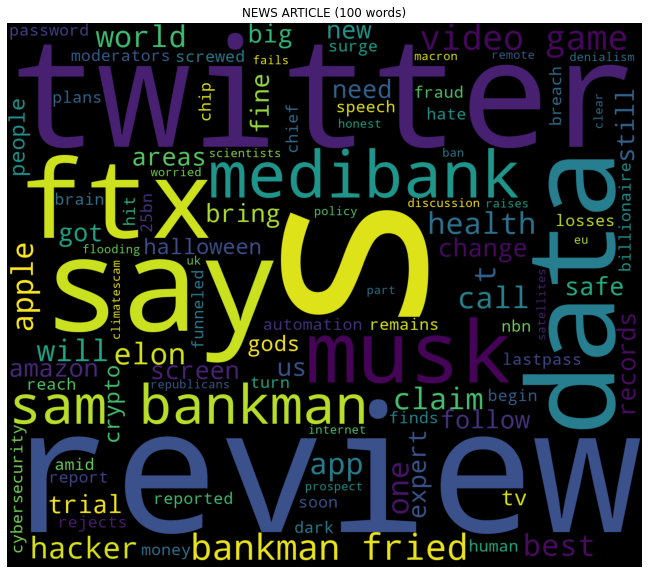

```python
# Plotting Word Cloud

plt.subplots(figsize=(16,10))
wordcloud = WordCloud(
                          background_color='black',
                          max_words=100,
                          width=1400,
                          height=1200
                         ).generate(cloud_words)
plt.imshow(wordcloud)
plt.title('NEWS ARTICLE (100 words)')
plt.axis('off')
plt.show()
```

## News from Google News

```python
from pygooglenews import GoogleNews

google_news = []

gn = GoogleNews()
s = gn.search('gold')

for entry in s["entries"]:
    google_news.append(entry["title"])

print(google_news)
```

```
['Gold retreats from near 4-month peak on positive U.S. jobs data - CNBC', 'Sentiment shows gold price has the momentum to move solidly above $1800 - Kitco NEWS', 'Gold and silver off to the races, or is this another false start - Kitco NEWS', 'Gold price powers to 3.5-mo. High, more upside likely -…
```

```python
cloud_words = ""

for val in google_news:
  val = str(val)
  tokens = val.split()
  for i in range(len(tokens)):
        tokens[i] = tokens[i].lower()
  cloud_words += " ".join(tokens)+" "
```

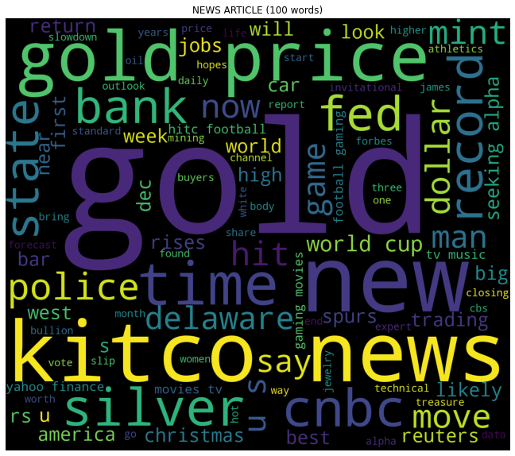

```python
# Plotting Word Cloud

plt.subplots(figsize=(16,10))
wordcloud = WordCloud(
                          background_color='black',
                          max_words=100,
                          width=1400,
                          height=1200
                         ).generate(cloud_words)
plt.imshow(wordcloud)
plt.title('NEWS ARTICLE (100 words)')
plt.axis('off')
plt.show()
```

## Part 1: Web Scraping the Articles

```python
# Getting news articles using get from request packagge

r=requests.get('https://www.kitco.com/news/2022-12-02/Sentiment-shows-gold-price-has-the-momentum-to-move-solidly-above-1-800.html')
```

```python
#Setting encoding of the HTML page
r.encoding = 'utf-8'
```

```python
# Extracting the HTML from the request object
html = r.text
```

```python
# Printing the first 500 characters in html
print(html[:500])
```

```
<!DOCTYPE html>
<html xmlns="http://www.w3.org/1999/xhtml" itemscope itemtype="http://schema.org/Article"><!-- InstanceBegin template="/Templates/media_article_v2.dwt" codeOutsideHTMLIsLocked="false" -->
	<head>


				<title>Sentiment shows gold price has the momentum to move solidly above $1,800 | Kitco News</title>
				<meta http-equiv="Content-Type" content="text/html; charset=utf-8" />
		<meta name="viewport" content="width=device-width, initial-scale=1">

		   <!-- p
```

```python
# Creating a BeautifulSoup object from the HTML
soup = BeautifulSoup(html)
# Getting the text out of the soup
text = soup.get_text()
```

```python
#total length
len(text)
```

```
17245
```

```python
#having a look at the text
print(text[100:1100])
```

[output not shown]

[output cut: 93 more lines]

[output not shown]

```python
# Text Cleaning

clean_text= text.replace("n", " ")
clean_text= clean_text.replace("/", " ")
clean_text= ''.join([c for c in clean_text if c != "'"])
```

```python
clean_text
```

```
'\n\nSe time t shows gold price has the mome tum to move solidly above $1,800 | Kitco News\n\n\n\n\n\n\n\n\n\n\n\n\n\n\n\n\n\n\n\n\n\n\n\n\n\n\n\n\n\n\n\n\n\n\n\n\n\n\n\n\n\n\n\n\n\n\n\n\n\n\n\n\n\n\n\n\n\n\n\n\n\n\n\n\n\n\n\n\n\n\n\n\n\n\n\n\n\n\n\n\n\n\n\n\n\n\n\n\n\n\n\n\nMake Kitco Your Homepage…
```

```python
sentence=[]
tokens = nlp(clean_text)
for sent in tokens.sents:
    sentence.append((sent.text.strip()))
```

```python
sentence
```

[output not shown]

[output cut: 116 more lines]

[output not shown]

```python
# Printing length of sentences

print(len(sentence))
```

```
171
```

```python
# Looking at the random sentence to verify
print(sentence[2])
```

```
e Store



Buy Gold & Silver


Great Deals


Gift Ideas


Cool a d Collectible


Gold


Gold Coi s


Gold Bars
```

## Part 2: Sentiment Analysis with Textblob

```python
textblob_sentiment=[]
for s in sentence:
    txt= TextBlob(s)
    a= txt.sentiment.polarity
    b= txt.sentiment.subjectivity
    textblob_sentiment.append([s,a,b])
```

```python
df_textblob = pd.DataFrame(textblob_sentiment, columns =['Sentence', 'Polarity', 'Subjectivity'])
```

```python
df_textblob.head()
```

|  | Sentence | Polarity | Subjectivity |
| --- | --- | --- | --- |
| 0 | Se time t shows gold price has the mome tum to... | 0.000000 | 0.100000 |
| 1 | Buy Sell Gold &\r\n\t\t\t\t\t\t\tSilver Bullio... | 0.000000 | 0.000000 |
| 2 | e Store\n\n\n\nBuy Gold & Silver\n\n\nGreat De... | 0.216667 | 0.733333 |
| 3 | Silver\n\n\nSilver Coi s\n\n\nSilver Rou ds\n\... | 0.000000 | 0.000000 |
| 4 | Coi s\n\n\nPlati um Bars\n\n\nPalladium\n\n\nR... | 0.000000 | 0.000000 |

```python
df_textblob.info()
```

```
<class 'pandas.core.frame.DataFrame'>
RangeIndex: 171 entries, 0 to 170
Data columns (total 3 columns):
 #   Column        Non-Null Count  Dtype
---  ------        --------------  -----
 0   Sentence      171 non-null    object
 1   Polarity      171 non-null    float64
 2   Subjectivity  171 non-null    float64
dtypes: float64(2), object(1)
memory usage: 4.1+ KB
```

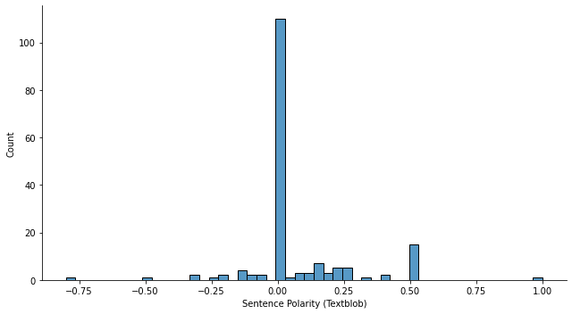

```python
# Analyzing polarity using visuals

sns.displot(df_textblob["Polarity"], height= 5, aspect=1.8)
plt.xlabel("Sentence Polarity (Textblob)")
```

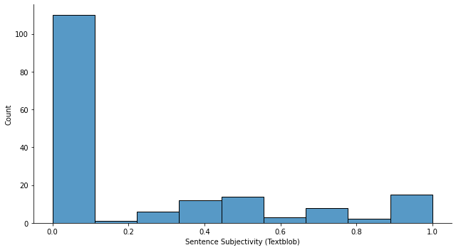

```python
# Analyzing subjectivity using visuals

sns.displot(df_textblob["Subjectivity"], height= 5, aspect=1.8)
plt.xlabel("Sentence Subjectivity (Textblob)")
```

The values of subjectivity also very with few sentences being highly subjective and a majority of sentences being less subjective.

```python
pattern_sentiment=[]
for s in sentence:
    res= sentiment(s)
    c= res[0]
    d= res[1]
    pattern_sentiment.append([s,c,d])
```

```python
pattern_sentiment[1]
```

```
['Buy Sell Gold &\r\n\t\t\t\t\t\t\tSilver Bullio  Coi s a d Bars\r\n\t\t\t\t\t\n\nO li',
 0.0,
 0.0]
```

```python
df_pattern = pd.DataFrame(textblob_sentiment, columns =['Sentence', 'Polarity', 'Subjectivity'])
```

```python
df_pattern.head()
```

|  | Sentence | Polarity | Subjectivity |
| --- | --- | --- | --- |
| 0 | Se time t shows gold price has the mome tum to... | 0.000000 | 0.100000 |
| 1 | Buy Sell Gold &\r\n\t\t\t\t\t\t\tSilver Bullio... | 0.000000 | 0.000000 |
| 2 | e Store\n\n\n\nBuy Gold & Silver\n\n\nGreat De... | 0.216667 | 0.733333 |
| 3 | Silver\n\n\nSilver Coi s\n\n\nSilver Rou ds\n\... | 0.000000 | 0.000000 |
| 4 | Coi s\n\n\nPlati um Bars\n\n\nPalladium\n\n\nR... | 0.000000 | 0.000000 |

```python
df_pattern.info()
```

```
<class 'pandas.core.frame.DataFrame'>
RangeIndex: 171 entries, 0 to 170
Data columns (total 3 columns):
 #   Column        Non-Null Count  Dtype
---  ------        --------------  -----
 0   Sentence      171 non-null    object
 1   Polarity      171 non-null    float64
 2   Subjectivity  171 non-null    float64
dtypes: float64(2), object(1)
memory usage: 4.1+ KB
```

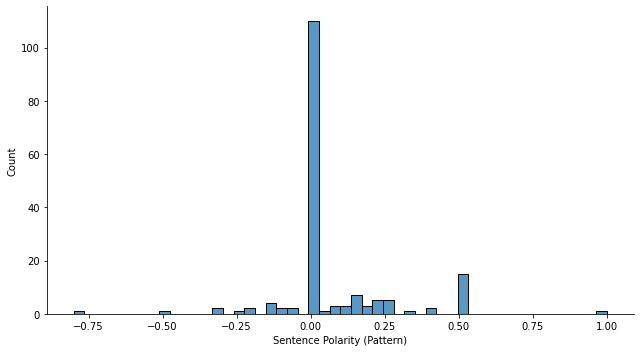

```python
# Plotting the scores

sns.displot(df_pattern["Polarity"], height= 5, aspect=1.8)
plt.xlabel("Sentence Polarity (Pattern)")
```

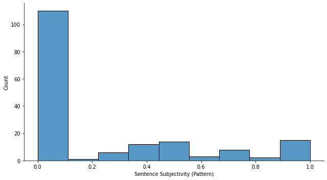

```python
sns.displot(df_pattern["Subjectivity"], height= 5, aspect=1.8)
plt.xlabel("Sentence Subjectivity (Pattern)")
```

## Part 4: Word frequency and Word Cloud

```python
# Creating the nltk tokenizer and Tokenizing text

tokens = nltk.tokenize.word_tokenize(clean_text)
```

```python
len(tokens)
```

```
3066
```

```python
print(tokens[0:10])
```

```
['Se', 'time', 't', 'shows', 'gold', 'price', 'has', 'the', 'mome', 'tum']
```

```python
# Converting to lower cases for uniformality

words = []
# Looping through the tokens and make them lower case
for word in tokens:
    words.append(word.lower())
```

```python
stopwords = nltk.corpus.stopwords.words('english')
```

```python
words_new = []
# Appending to words_new all words that are in words but not in stopwords
for word in words:
    if word not in stopwords:
        words_new.append(word)
```

```python
len(words_new)
```

```
2350
```

```python
print(words_new[0:10])
```

```
['se', 'time', 'shows', 'gold', 'price', 'mome', 'tum', 'move', 'solidly', '$']
```

```python
# The frequency distribution of the words

freq_dist = nltk.FreqDist(words_new)
```

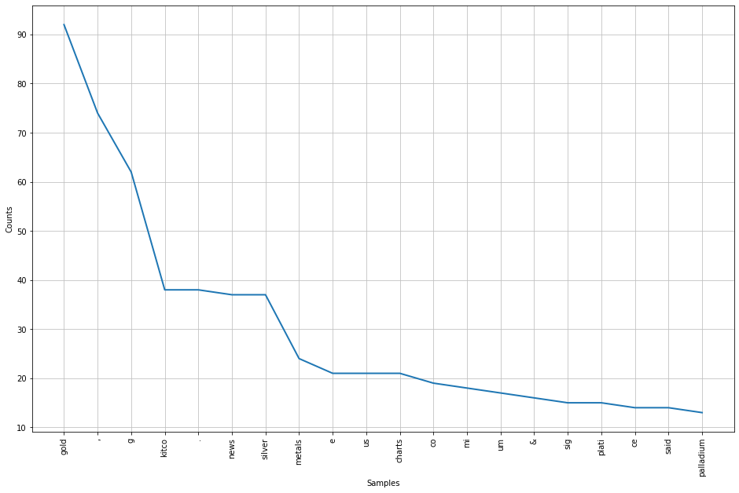

```python
# Frequency Distribution Plot

plt.subplots(figsize=(16,10))
freq_dist.plot(20)
```

```python
# Converting into string

res=' '.join([i for i in words_new if not i.isdigit()])
```

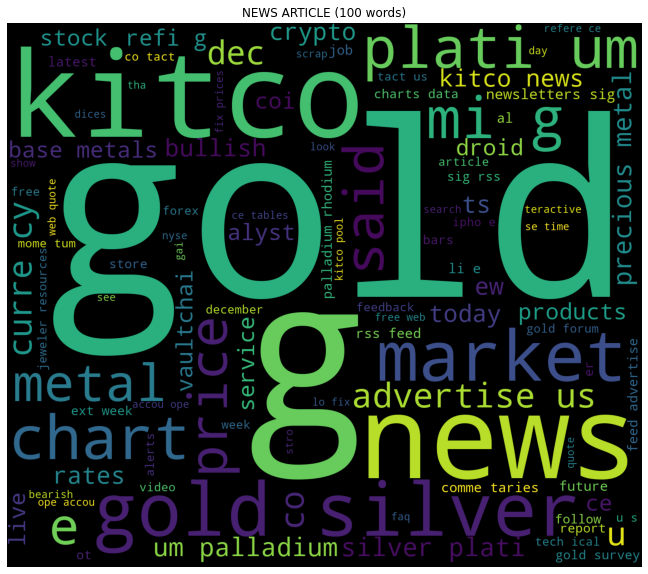

```python
# Plotting Word Cloud

plt.subplots(figsize=(16,10))
wordcloud = WordCloud(
                          background_color='black',
                          max_words=100,
                          width=1400,
                          height=1200
                         ).generate(res)
plt.imshow(wordcloud)
plt.title('NEWS ARTICLE (100 words)')
plt.axis('off')
plt.show()
```